# ggplot2 그래프

## ※ geom_bar() .vs. geom_col()

#### geom_bar() 원자료를 이용해 빈도를 그래프로 작성

#### geom_col() 요약값 계산 후 그래프로 작성(크기순 정렬 가능)

## 차종별 고속도로연비 합계를 나타내는 막대그래프

먼저, **geom_col()** 사용하여 차종(class) 별 고속도로연비(hwy)의 합계를 막대그래프를 그려본다. geom_col()은 x축과 y축 모두에 변수를 지정해야 한다.

```r
df_mpg <- mpg %>% group_by(class) %>% summarise(sum_hwy=sum(hwy))
df_mpg
```

```
## # A tibble: 7 x 2
##   class      sum_hwy
##   <chr>        <int>
## 1 2seater        124
## 2 compact       1330
## 3 midsize       1119
## 4 minivan        246
## 5 pickup         557
## 6 subcompact     985
## 7 suv           1124
```

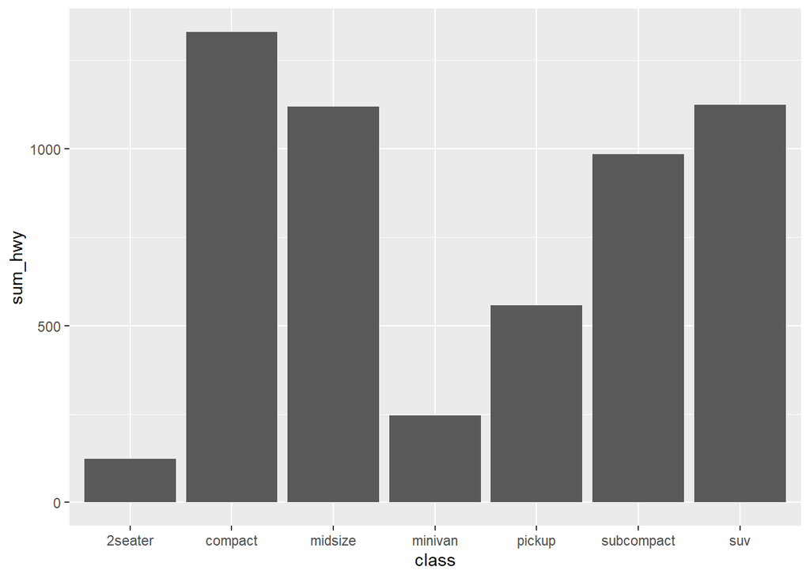

```r
ggplot(df_mpg, aes(x=class, y=sum_hwy)) + geom_col()
```

평균, 갯수, 최대값 등의 요약통계가 아닌 **합계**에 대한 막대그래프를 작성할 경우 아래와 같이 y축에 hwy 변수만 지정해도 된다.

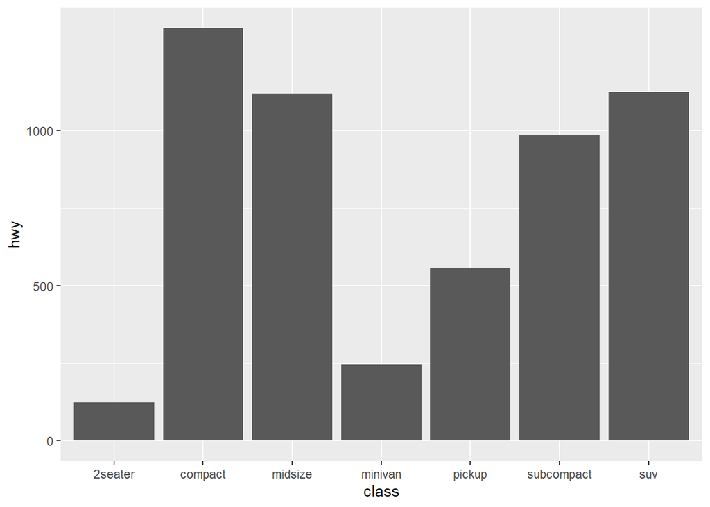

```r
ggplot(mpg, aes(x=class, y=hwy)) + geom_col()
```

geom_bar()를 사용하여 합계와 같은 막대그래프를 그리려면 **stat=‘identity’** 옵션을 사용해야 한다. geom_bar()는 그래프를 히스토그램화하는 기본 속성을 가지고 있기 때문이다.

```r
ggplot(mpg, aes(x=class, y=hwy)) + geom_bar(stat='identity')
```

[output not shown]

## ※ 사용하기 편한 것 선택

### **goem_col()** 빈도(범주) 또는 값을 막대그래프 표현하기 수월

## 제조회사별 평균 고속도로연비를 나타내는 막대그래프

geom_col()을 사용하여 제조회사(manufacturer)별 평균 고속도로연비(hwy)에 대한 막대그래프를 그리려면, 먼저 제조회사별 평균 고속도로연비를 계산해야 한다.

```r
df_mpg <- mpg %>% group_by(manufacturer) %>%
  summarise(mean_hwy=mean(hwy))
df_mpg
```

```
## # A tibble: 15 x 2
##    manufacturer mean_hwy
##    <chr>           <dbl>
##  1 audi             26.4
##  2 chevrolet        21.9
##  3 dodge            17.9
##  4 ford             19.4
##  5 honda            32.6
##  6 hyundai          26.9
##  7 jeep             17.6
##  8 land rover       16.5
##  9 lincoln          17
## 10 mercury          18
## 11 nissan           24.6
## 12 pontiac          26.4
## 13 subaru           25.6
## 14 toyota           24.9
## 15 volkswagen       29.2
```

계산된 평균값을 y축 변수에 지정하고 값의 크기 순으로 오름차순으로 정렬하여 그래프를 그리면 다음과 같다.

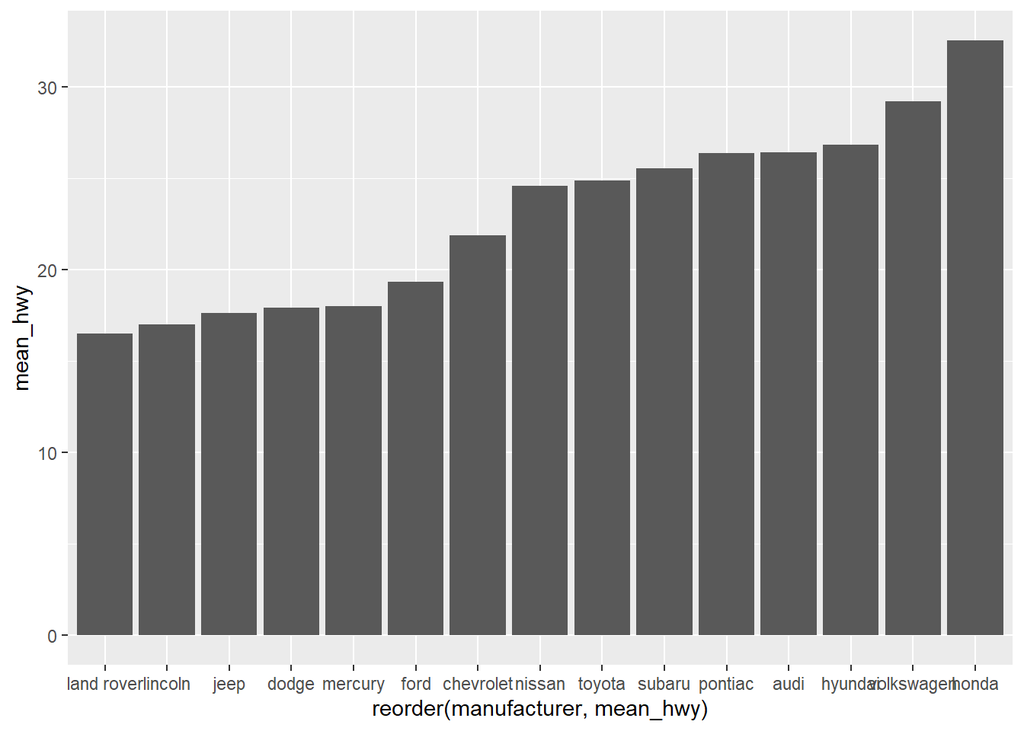

```r
ggplot(df_mpg, aes(x=reorder(manufacturer, mean_hwy), y=mean_hwy)) +
  geom_col()
```

### 좀 더 그래프를 꾸며보자.

그래프의 제목과 x축 및 y축의 제목을 달기 위해 **labs()**를 사용한다.

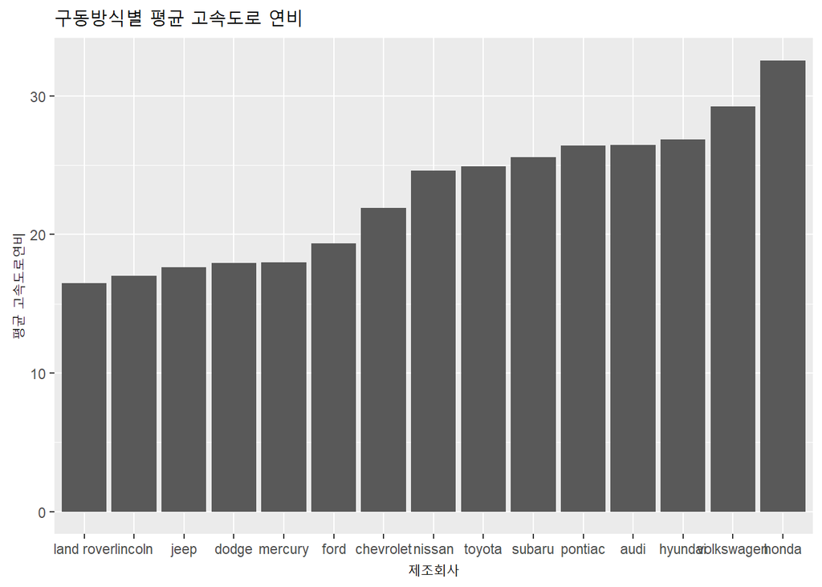

```r
ggplot(df_mpg, aes(x=reorder(manufacturer, mean_hwy), y=mean_hwy)) +
  geom_col() +
  labs(title="구동방식별 평균 고속도로 연비",
       x="제조회사", y="평균 고속도로연비")
```

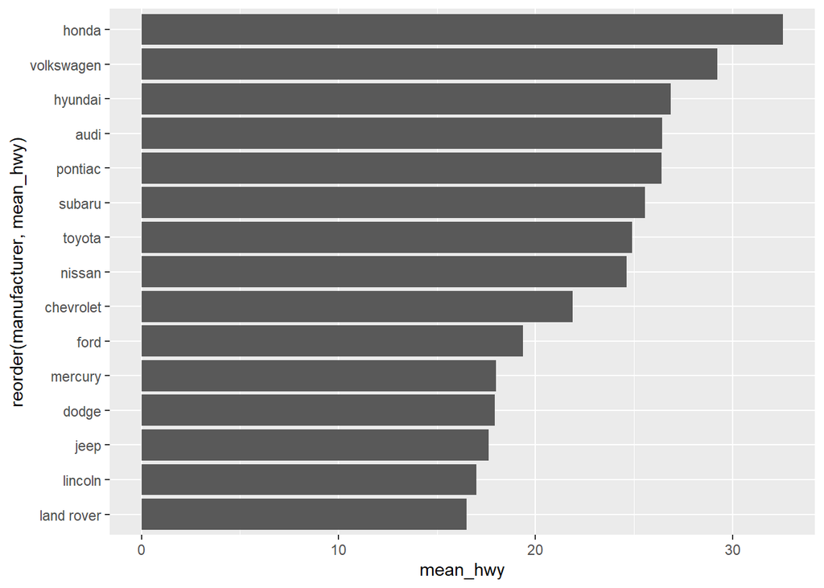

```r
ggplot(df_mpg, aes(x=reorder(manufacturer, mean_hwy), y=mean_hwy)) +
  geom_col() +
  coord_flip()
```

geom_text()을 추가하면 각 막대그래프의 값을 그래프에 나타낼 수 있다. 아래 R코드에서 x축과 y축 제목을 보이지 않도록 하기 위해 ""을 지정했다.

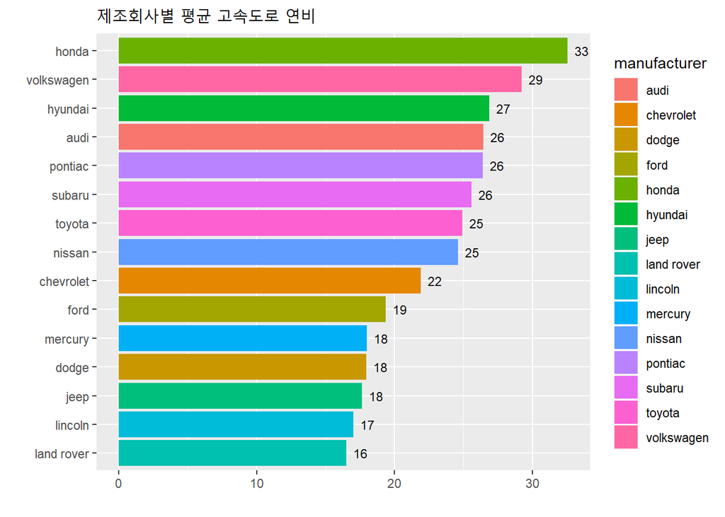

```r
ggplot(df_mpg, aes(x=reorder(manufacturer, mean_hwy),y=mean_hwy)) +
  geom_col(aes(fill=manufacturer)) +
  coord_flip() +
  geom_text(aes(label=round(mean_hwy)), hjust=-0.5, size=3) +
  labs(title="제조회사별 평균 고속도로 연비", x="", y="")
```